# M2.891_20251_PEC1-Enunciado

# Conjuntos desbalanceados de datos (1.5 puntos)

En los problemas con variables objetivo discretas, con valores acotados, es muy común encontrar conjuntos de datos muy desbalanceados. En la industria existen múltiples ejemplos, como la detección de fraude o la fuga de clientes. Este apartado se centra en el análisis de este tipo de conjuntos.

El caso del *dataset* con el que estamos trabajando es uno de ellos, ya que podemos ver cómo el tamaño de las clases 0 y 1 es inmensamente mayor que el del resto.

A continuación, vamos a analizar la distribución de nuestro conjunto de datos. Para ello, utilizaremos la función show_distribution definida en la siguiente celda:

```python
def show_distribution(y_df):
    freq = y_df.value_counts().sort_index()
    plt.pie(
        freq,
        labels=(
            f"sin accidentes ({freq[0]}))",
            f"leve ({freq[1]}))",
            f"grave ({freq[2]}))",
            f"mortal ({freq[3]}))",
        ),
        autopct='%1.1f%%'
    )
    plt.title("Gravedad del accidente")
    plt.show()
```

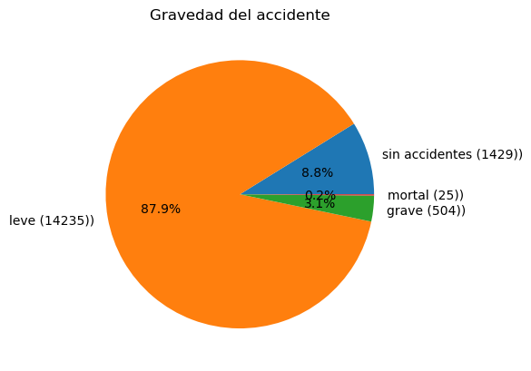

```python
show_distribution(y)
```

Cómo se puede observar, el conjunto está bastante desbalanceado, ya que el número de muestras correspondientes a accidentes graves o mortales es mínusculo.

Para abordar el problema de datos desbalanceados, vamos a analizar la técnica de sobremuestreo (oversampling) de la clase minoritaria. En la literatura hay más técnicas que tratan de solucionar este problema, como el submuestreo (undersampling) de la clase mayoritaria, pero en esta PEC nos vamos a centrar sólo en la técnica de sobremuestreo, ya que no disponemos de un gran número de muestras que no sean de las clases mayoritarias.

**Ejercicio:** incrementad las muestras de la clase minoritaria hasta alcanzar un número similar al de elementos de la clase mayoritaria, aplicando las siguientes técnicas:

- Duplicación aleatoria (random over-sampling), fijando random_state=10.
- SMOTE (Synthetic Minority Over-sampling Technique), fijando random_state=10.
- ADASYN (Adaptive Synthetic Sampling), fijando random_state=10.

Por último, comprobad, con ayuda de la función **show_distribution**, que después de la aplicación de dichas técnicas el número de muestras de la clase minoritaria se ha igualado al de la mayoritaria.

Sugerencia: para aplicar la duplicación aleatoria podéis usar "RandomOverSampler" de *imblearn*. Sugerencia: para aplicar smote podéis usar "SMOTE" de *imblearn*. Sugerencia: para aplicar adasun podéis usar "ADASYN" de *imblearn*.

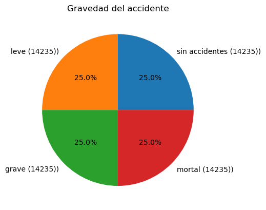

```python
ros = RandomOverSampler(random_state=seed)
X_ros, y_ros = ros.fit_resample(X, y)

show_distribution(y_ros)
```

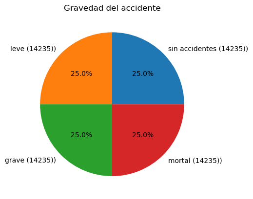

```python
smote = SMOTE(random_state=seed)
X_smote, y_smote = smote.fit_resample(X, y)

show_distribution(y_smote)
```

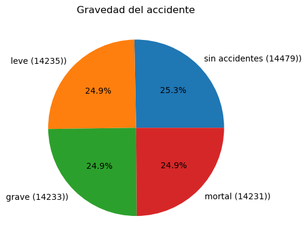

```python
adasyn = ADASYN(random_state=seed)
X_adasyn, y_adasyn = adasyn.fit_resample(X, y)

show_distribution(y_adasyn)
```

El resultado de aplicar dichas técnicas nos debería de haber dado un número similar de muestras para todas las clases, sin embargo, cada uno de los métodos genera las nuevas muestras de la clase minoritaria de diferente forma. Con el objetivo de comprender mejor y de manera visual cómo se generan estas nuevas muestras utilizaremos, a partir de ahora, la descomposición a dos dimensiones que mejor se haya comportado en el apartado anterior.

**Ejercicio:** mostrad, mediante un *scatter plot* en función de las dos componentes a las que anteriormente hemos reducido el *dataset*, la distribución de una de las clases minoritarias del conjunto de datos original y el obtenido al aplicar cada una de las técnicas.

```python
# Transformamos cada conjunto sobre t-SNE
X_ros_tsne = tsne.fit_transform(X_ros)
X_smote_tsne = tsne.fit_transform(X_smote)
X_adasyn_tsne = tsne.fit_transform(X_adasyn)

# Convertir a DataFrames y filtrar clase minoritaria
df_ros = pd.DataFrame(X_ros_tsne, columns=['Dim1', 'Dim2'])
df_ros['Gravedad'] = y_ros
df_ros_minor = df_ros[df_ros['Gravedad'] == 2]

df_smote = pd.DataFrame(X_smote_tsne, columns=['Dim1', 'Dim2'])
df_smote['Gravedad'] = y_smote
df_smote_minor = df_smote[df_smote['Gravedad'] == 2]

df_adasyn = pd.DataFrame(X_adasyn_tsne, columns=['Dim1', 'Dim2'])
df_adasyn['Gravedad'] = y_adasyn
df_adasyn_minor = df_adasyn[df_adasyn['Gravedad'] == 2]

df_tsne_minor = df_tsne[df_tsne['Gravedad'] == 2]
```

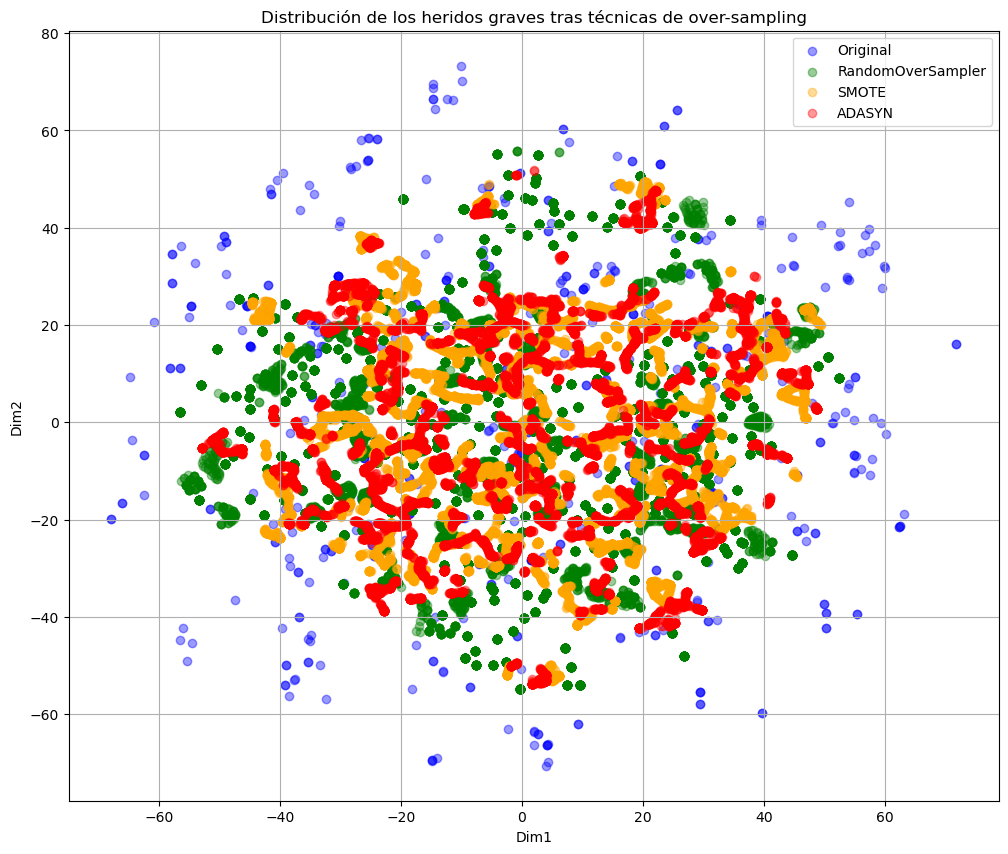

```python
plt.figure(figsize=(12,10))

# Clase original
plt.scatter(df_tsne_minor['Dim1'], df_tsne_minor['Dim2'],
            color='blue', alpha=0.4, label='Original')

# RandomOverSampler
plt.scatter(df_ros_minor['Dim1'], df_ros_minor['Dim2'],
            color='green', alpha=0.4, label='RandomOverSampler')

# SMOTE
plt.scatter(df_smote_minor['Dim1'], df_smote_minor['Dim2'],
            color='orange', alpha=0.4, label='SMOTE')

# ADASYN
plt.scatter(df_adasyn_minor['Dim1'], df_adasyn_minor['Dim2'],
            color='red', alpha=0.4, label='ADASYN')

plt.xlabel('Dim1')
plt.ylabel('Dim2')
plt.title('Distribución de los heridos graves tras técnicas de over-sampling')
plt.legend()
plt.grid(True)
plt.show()
```

**Análisis:** comentad los resultados.

Tras aumentar las muestras de una clase de gravedad, en este caso de accidentes con heridos graves, hemos comparado las 3 técnicas diferentes con la que lo hemos ampliado en una gráfica de 2 dimensiones que hemos creado con el t-SNE.

En conclusión, ninguna técnica es perfecta, ya que genera nuevos datos no reales a partir de los originales y la calidad de estos no siempre es la esperada, con estas tres técnicas con ninguna hemos obtenido los valores esperados.

# Búsqueda y combinación de nuevos conjuntos de datos (1 punto)

En este apartado os animamos a que busquéis de manera libre un nuevo conjunto de datos que podáis combinar de alguna forma (a través de alguno o algunos atributos comunes) con el conjunto de datos inicial para enriquecer más aún la información que tenemos de cada accidente de cara a estimar mejor su gravedad.

Es inprescindible que, una vez tengáis el conjunto de datos ampliado con el cálculo de vuestros nuevos atributos descriptivos procedentes del nuevo *dataset*, reejecutéis todo el Notebook, a excepción de la carga inicial del conjunto de datos, para comprobar el efecto de dicha ampliación.

He encontrado, buscando en el open data de barcelona datos extra sobre la descripción del vehículo, lo relacionaré a partir del número de accidente, ya que, al sacar la información de la misma página supongo que estará estandarizado. El dataset lo he sacado de https://opendata-ajuntament.barcelona.cat/data/es/dataset/accidents-vehicles-gu-bcn

Y para relacionarlo habría que realizar lo siguiente:

### 1. Modificar la carga y añadir el número de accidente

```python
# Carga de archivos en DataFrames
df_2023 = pd.read_csv("./data/2023_accidents_gu_bcn.csv")
df_2024 = pd.read_csv("./data/2024_accidents_gu_bcn.csv")
df_carrerer = pd.read_csv("./data/carrerer.csv")

# Concatenar en un solo DataFrame información de accidentes
df_concat = pd.concat([df_2023, df_2024])

# Incorporar información sobre la gravedad del accidente
df_concat["Gravedad"] = np.select(
    [
        df_concat["Numero_morts"] > 0,
        df_concat["Numero_lesionats_greus"] > 0,
        df_concat["Numero_lesionats_lleus"] > 0
    ],
    [3, 2, 1],
    default=0
)

# Incorporar el tipo de vía
df_concat["Codi_carrer"].astype(str) # Transformar a str como en carrerer
mapping = df_carrerer.set_index('codi_via')['tipus_via']
df_concat['tipus_via'] = df_concat['Codi_carrer'].map(mapping)

# Crear la fecha a partir del día mes y año para facilitar tarea de después
df_concat['Fecha'] = pd.to_datetime({
    'year': df_concat['NK_Any'],
    'month': df_concat['Mes_any'],
    'day': df_concat['Dia_mes']
})

# Crear el DataFrame que usaremos en adelante
df = df_concat[[
        'Numero_expedient',
        'Longitud_WGS84',
        'Latitud_WGS84',
        'tipus_via',
        'Descripcio_dia_setmana',
        'Fecha',
        'Hora_dia',
        'Gravedad'
    ]].copy()
```

### 2. Juntar por número de expediente y quitar los nulos del tipo de via

```python
# Carga de los nuevos conjuntos
df_v_23 = pd.read_csv("./data/2023_accidents_vehicles_gu_bcn.csv")
df_v_24 = pd.read_csv("./data/2024_accidents_vehicles_gu_bcn.csv")


df_v_concat = pd.concat([df_v_23, df_v_24])
# Eliminar espacios
df_v_concat["Numero_expedient"] = df_v_concat["Numero_expedient"].str.strip()

df = df.merge(
    df_v_concat[
        [
            "Numero_expedient",
            "Descripcio_tipus_vehicle"
        ]
    ],
    left_on="Numero_expedient",
    right_on="Numero_expedient",
    how="inner"
).drop(columns="Numero_expedient")

# Calcular el valor más frecuente (moda) de la columna
moda_tipus_via = df['tipus_via'].mode()[0]

# Rellenar los valores nulos con esa moda
df.fillna({'tipus_via' : moda_tipus_via}, inplace=True)
```

### 3. Continuar desde la carga y el merge de aemet del principio

He dejado el notebook con la versión de vehículos incluido por si no se quiere descargar los datos y poder visualizarlo, se pueden descargar los datos del enlace de arriba de open data de BCN con los datasets del 2023 y 2024.

Como cambio sí que veo una ligera mejoría en los dos métodos de reducción de variables sin over-sampling, se puede ver alguna zona con más concentración de accidentes on un tipo de gravedad con que podría ser un buen atributo descriptivo el añadido.

### **Aclaración** todos los análisis se han realizado sin contar el tipo de vehículo, ese atributo es el extra que se ha metido en el ejercicio final. En ese apartado se explica de donde sacar estos nuevos datos y cómo mergearlos, para ver el original simplemente ejecutar todo y estos datos no estarán, se mantendrá esta versión en el HTML enviado.